# What makes a romance work?

A survey of 3510 individuals conducted by Stanford University in 2017 sought to determine the modern methods by which couples meet and stay together. The survey asks questions about the demographic information of the respondents as well as how they met their current partner. Link to source: https://data.stanford.edu/hcmst

Using the partnership status of the respondents as the target, various algorithms will be tested to optimize classification of married and unmarried respondents.

As the penalty for misclassification is equal in this case study for Type I and II errors, the F1 score will be used to gauge model accuracy and selection.

```python
import pandas as pd
import numpy as np
import matplotlib.pyplot as plt
import seaborn as sns
import scikitplot as skplt
from collections import defaultdict
from sklearn import ensemble
from sklearn.model_selection import train_test_split
from scipy.stats.mstats import winsorize
from scipy.stats import ttest_ind
import category_encoders as ce
from sklearn.model_selection import GridSearchCV
from sklearn.model_selection import cross_val_score
from sklearn.feature_selection import RFECV
from sklearn.metrics import confusion_matrix
from sklearn.metrics import f1_score
from sklearn.linear_model import LogisticRegression
from sklearn.svm import SVC
from sklearn.datasets import make_classification


sns.set_style('darkgrid')
```

```python
#Convert STATA files to readable CSV
data = pd.io.stata.read_stata('HCMST 2017 fresh sample for public sharing draft v1.1.dta')
data.to_csv('Couples.csv')
couples= pd.read_csv('Couples.csv')
couples.head()
```

|  | Unnamed: 0 | CaseID | CASEID_NEW | qflag | weight1 | weight1_freqwt | weight2 | weight1a | weight1a_freqwt | weight_combo | ... | hcm2017q24_met_through_family | hcm2017q24_met_through_friend | hcm2017q24_met_through_as_nghbrs | hcm2017q24_met_as_through_cowork | w6_subject_race | interracial_5cat | partner_mother_yrsed | subject_mother_yrsed | partner_yrsed | subject_yrsed |
| --- | --- | --- | --- | --- | --- | --- | --- | --- | --- | --- | --- | --- | --- | --- | --- | --- | --- | --- | --- | --- | --- |
| 0 | 0 | 2 | 2014039 | Qualified | NaN | NaN | 0.8945 | NaN | NaN | 0.277188 | ... | no | no | no | no | White | no | 12.0 | 14.0 | 12.0 | 14.0 |
| 1 | 1 | 3 | 2019003 | Qualified | 0.9078 | 71115.0 | NaN | 0.9026 | 70707.0 | 1.020621 | ... | no | no | no | yes | White | no | 12.0 | 16.0 | 17.0 | 17.0 |
| 2 | 2 | 5 | 2145527 | Qualified | 0.7205 | 56442.0 | NaN | 0.7164 | 56121.0 | 0.810074 | ... | no | no | no | no | White | no | 9.0 | 7.5 | 14.0 | 17.0 |
| 3 | 3 | 6 | 2648857 | Qualified | 1.2597 | 98682.0 | 1.3507 | 1.2524 | 98110.0 | 0.418556 | ... | no | no | no | no | White | no | 16.0 | 12.0 | 12.0 | 12.0 |
| 4 | 4 | 7 | 2623465 | Qualified | 0.8686 | 68044.0 | NaN | 0.8636 | 67652.0 | 0.976522 | ... | no | no | yes | no | White | no | 14.0 | 17.0 | 16.0 | 16.0 |

5 rows × 286 columns

```python
couples.shape
```

```
(3510, 286)
```

```python
#Check the first column for index duplicates
all(couples.iloc[:, 0]==couples.index)
```

```
True
```

```python
#Drop column
couples= couples.drop('Unnamed: 0', axis=1)
#Drop ID columns
couples=couples.drop(['CaseID', 'CASEID_NEW'], axis=1)
```

```python
couples.info()
```

```
<class 'pandas.core.frame.DataFrame'>
RangeIndex: 3510 entries, 0 to 3509
Columns: 283 entries, qflag to subject_yrsed
dtypes: float64(40), int64(9), object(234)
memory usage: 7.6+ MB
```

```python
#Isolate columns with >60% nulls
null_counts= couples.isnull().sum().sort_values(ascending=False)
high_nulls= null_counts[null_counts>2106]
high_nulls
```

```
Q16_2_Codes            3503
Q3_Refused             3501
w6_how_meet_Refused    3498
Q16_Refused            3490
w6_how_many_app_2      3470
                       ...
weight2                2959
w6_q5                  2901
S3                     2862
Q17B                   2733
w6_q20                 2507
Length: 78, dtype: int64
```

```python
#Drop high null columns
couples= couples.drop(high_nulls.index, axis=1)
```

```python
#Inspect remaining
couples.isnull().sum().sort_values(ascending=False)
```

```
Q17D       2096
S2         2085
Q17C       2068
Q26        1913
w6_q26     1711
           ...
PPT25         0
PPT612        0
PPT1317       0
PPT18OV       0
qflag         0
Length: 205, dtype: int64
```

```python
#Find categorical columns with >15 categories
categorical = couples.select_dtypes(include=['object'])
heavy_cats=[]
for i in categorical:
    column = categorical[i]
    if column.nunique()>15:
        print(i)
        heavy_cats.append(i)
```

```
Q9
Q21A_Year
Q21B_Year
Q21C_Year
Q21D_Year
ppincimp
```

```python
#Inspect YEAR vars
couples[heavy_cats]
```

|  | Q9 | Q21A_Year | Q21B_Year | Q21C_Year | Q21D_Year | ppincimp |
| --- | --- | --- | --- | --- | --- | --- |
| 0 | NaN | NaN | NaN | NaN | NaN | $40,000 to $49,999 |
| 1 | 52.0 | 1983 | 1995 | 1996 | 1996 | $150,000 to $174,999 |
| 2 | 45.0 | 2006 | 2006 | 2006 | 2008 | $200,000 to $249,999 |
| 3 | NaN | NaN | NaN | NaN | NaN | $40,000 to $49,999 |
| 4 | 59.0 | 1983 | 1983 | 1984 | 1984 | $175,000 to $199,999 |
| 5 | 60.0 | 1981 | 1982 | 1982 | 1982 | $75,000 to $84,999 |
| 6 | 67.0 | 1966 | 1967 | 1969 | 1969 | $50,000 to $59,999 |
| 7 | 65.0 | 1967 | 1967 | 1970 | 1970 | $60,000 to $74,999 |
| 8 | NaN | NaN | NaN | NaN | NaN | $125,000 to $149,999 |
| 9 | NaN | NaN | NaN | NaN | NaN | $15,000 to $19,999 |
| 10 | 43.0 | 2008 | 2008 | 2008 | 2008 | $250,000 or more |
| 11 | NaN | NaN | NaN | NaN | NaN | $150,000 to $174,999 |
| 12 | NaN | NaN | NaN | NaN | NaN | $175,000 to $199,999 |
| 13 | NaN | NaN | NaN | NaN | NaN | $75,000 to $84,999 |
| 14 | 35.0 | 2007 | 2011 | 2012 | 2012 | $200,000 to $249,999 |
| 15 | 42.0 | 2002 | 2004 | 2006 | 2011 | $85,000 to $99,999 |
| 16 | 37.0 | 2007 | 2007 | 2013 | NaN | $100,000 to $124,999 |
| 17 | 40.0 | 2002 | 2002 | 2004 | 2007 | $20,000 to $24,999 |
| 18 | 40.0 | 2004 | 2006 | 2007 | 2007 | $100,000 to $124,999 |
| 19 | 72.0 | 1973 | 1974 | 1974 | 1974 | $60,000 to $74,999 |
| 20 | 40.0 | 1995 | 1995 | 1998 | 2000 | $250,000 or more |
| 21 | NaN | NaN | NaN | NaN | NaN | $175,000 to $199,999 |
| 22 | NaN | NaN | NaN | NaN | NaN | $40,000 to $49,999 |
| 23 | 55.0 | 2008 | 2011 | NaN | NaN | $15,000 to $19,999 |
| 24 | 35.0 | 2000 | 2000 | 2001 | 2008 | $20,000 to $24,999 |
| 25 | 45.0 | 1990 | 1990 | 1990 | 1990 | $30,000 to $34,999 |
| 26 | NaN | NaN | NaN | NaN | NaN | $100,000 to $124,999 |
| 27 | 25.0 | 2014 | 2015 | NaN | NaN | $10,000 to $12,499 |
| 28 | 43.0 | 2012 | 2017 | NaN | NaN | $75,000 to $84,999 |
| 29 | 22.0 | 2010 | 2010 | 2012 | NaN | $25,000 to $29,999 |
| ... | ... | ... | ... | ... | ... | ... |
| 3480 | 51.0 | 1994 | 1994 | 1996 | 2012 | $150,000 to $174,999 |
| 3481 | 21.0 | 2011 | 2013 | 2013 | NaN | $5,000 to $7,499 |
| 3482 | 29.0 | 2015 | 2015 | 2016 | NaN | $30,000 to $34,999 |
| 3483 | 37.0 | 2008 | 2008 | 2008 | 2011 | $50,000 to $59,999 |
| 3484 | 26.0 | 2010 | 2011 | 2013 | NaN | $40,000 to $49,999 |
| 3485 | 32.0 | 2011 | 2012 | 2014 | NaN | $125,000 to $149,999 |
| 3486 | NaN | NaN | NaN | NaN | NaN | $50,000 to $59,999 |
| 3487 | 60.0 | 1996 | 2001 | 2002 | 2014 | $40,000 to $49,999 |
| 3488 | 56.0 | 1987 | 1988 | 1989 | 1990 | $250,000 or more |
| 3489 | 56.0 | 1998 | 1998 | 1998 | 1998 | $100,000 to $124,999 |
| 3490 | 32.0 | 2014 | 2014 | 2015 | NaN | $75,000 to $84,999 |
| 3491 | 49.0 | 2000 | 2000 | 2002 | 2011 | $100,000 to $124,999 |
| 3492 | NaN | NaN | NaN | NaN | NaN | $60,000 to $74,999 |
| 3493 | NaN | NaN | NaN | NaN | NaN | $40,000 to $49,999 |
| 3494 | NaN | NaN | NaN | NaN | NaN | $25,000 to $29,999 |
| 3495 | 28.0 | 2016 | 2017 | NaN | NaN | $40,000 to $49,999 |
| 3496 | 46.0 | 1998 | 1999 | 1999 | 1999 | $35,000 to $39,999 |
| 3497 | 35.0 | 2011 | 2011 | 2011 | NaN | $15,000 to $19,999 |
| 3498 | 44.0 | 2015 | 2015 | 2015 | 2016 | $12,500 to $14,999 |
| 3499 | 32.0 | 2013 | 2014 | 2014 | NaN | $75,000 to $84,999 |
| 3500 | 67.0 | 1978 | 1978 | 1978 | 1980 | $50,000 to $59,999 |
| 3501 | 24.0 | 2016 | 2016 | 2017 | NaN | $25,000 to $29,999 |
| 3502 | 42.0 | 1996 | 1996 | 1996 | 2001 | $125,000 to $149,999 |
| 3503 | 43.0 | 1994 | 1994 | NaN | NaN | $150,000 to $174,999 |
| 3504 | NaN | NaN | NaN | NaN | NaN | $40,000 to $49,999 |
| 3505 | 29.0 | 2015 | 2015 | 2015 | 2017 | $60,000 to $74,999 |
| 3506 | 21.0 | 2016 | 2017 | NaN | NaN | $250,000 or more |
| 3507 | 39.0 | 2012 | 2012 | 2013 | 2016 | $125,000 to $149,999 |
| 3508 | 28.0 | 2014 | 2015 | 2016 | NaN | $60,000 to $74,999 |
| 3509 | 43.0 | 2015 | 2015 | 2015 | NaN | $40,000 to $49,999 |

3510 rows × 6 columns

```python
#Inspect household income variable
couples.ppincimp.unique()
```

```
array(['$40,000 to $49,999', '$150,000 to $174,999',
       '$200,000 to $249,999', '$175,000 to $199,999',
       '$75,000 to $84,999', '$50,000 to $59,999', '$60,000 to $74,999',
       '$125,000 to $149,999', '$15,000 to $19,999', '$250,000 or more',
       '$85,000 to $99,999', '$100,000 to $124,999', '$20,000 to $24,999',
       '$30,000 to $34,999', '$10,000 to $12,499', '$25,000 to $29,999',
       '$5,000 to $7,499', '$7,500 to $9,999', '$35,000 to $39,999',
       'Less than $5,000', '$12,500 to $14,999'], dtype=object)
```

```python
#Create algorithm to parse income boundaries
def getIntValue(s):
    return int(''.join(s[1:].split(',')))

def parse_bounds(s):
    if 'Less than ' in s:
            return [0, 5000]
    elif ' or more' in s:
            s = s.split(" or more")
            a = getIntValue(s[0])
            return [a, a+50000]
    s=s.split(" to ")
    return [getIntValue(s[0]), getIntValue(s[1])]


bounds_list=[]
for x in couples.ppincimp.unique():
    results= parse_bounds(x)
    bounds_list.append(results)

for x in bounds_list:
    print(x)
```

```
[40000, 49999]
[150000, 174999]
[200000, 249999]
[175000, 199999]
[75000, 84999]
[50000, 59999]
[60000, 74999]
[125000, 149999]
[15000, 19999]
[250000, 300000]
[85000, 99999]
[100000, 124999]
[20000, 24999]
[30000, 34999]
[10000, 12499]
[25000, 29999]
[5000, 7499]
[7500, 9999]
[35000, 39999]
[0, 5000]
[12500, 14999]
```

```python
#Sort bounds_list by minimum left value
bounds_means= [(x[1]+x[0])/2 for x in bounds_list]
bounds_means
```

```
[44999.5,
 162499.5,
 224999.5,
 187499.5,
 79999.5,
 54999.5,
 67499.5,
 137499.5,
 17499.5,
 275000.0,
 92499.5,
 112499.5,
 22499.5,
 32499.5,
 11249.5,
 27499.5,
 6249.5,
 8749.5,
 37499.5,
 2500.0,
 13749.5]
```

```python
#Create loop zipping in ppincimp keys to bounds_means values
income_dict= dict(zip(couples.ppincimp.unique(), bounds_means))
income_dict
```

```
{'$40,000 to $49,999': 44999.5,
 '$150,000 to $174,999': 162499.5,
 '$200,000 to $249,999': 224999.5,
 '$175,000 to $199,999': 187499.5,
 '$75,000 to $84,999': 79999.5,
 '$50,000 to $59,999': 54999.5,
 '$60,000 to $74,999': 67499.5,
 '$125,000 to $149,999': 137499.5,
 '$15,000 to $19,999': 17499.5,
 '$250,000 or more': 275000.0,
 '$85,000 to $99,999': 92499.5,
 '$100,000 to $124,999': 112499.5,
 '$20,000 to $24,999': 22499.5,
 '$30,000 to $34,999': 32499.5,
 '$10,000 to $12,499': 11249.5,
 '$25,000 to $29,999': 27499.5,
 '$5,000 to $7,499': 6249.5,
 '$7,500 to $9,999': 8749.5,
 '$35,000 to $39,999': 37499.5,
 'Less than $5,000': 2500.0,
 '$12,500 to $14,999': 13749.5}
```

```python
#Replace values with income_dict values
couples.ppincimp= couples.ppincimp.map(income_dict)
couples.ppincimp
```

```
0        44999.5
1       162499.5
2       224999.5
3        44999.5
4       187499.5
          ...
3505     67499.5
3506    275000.0
3507    137499.5
3508     67499.5
3509     44999.5
Name: ppincimp, Length: 3510, dtype: float64
```

```python
# Convert Year & Age variables to numeric
for col in couples[heavy_cats].iloc[:, :-1]:
    couples[col]= pd.to_numeric(couples[col], errors='coerce')
```

```python
couples[heavy_cats].describe()
```

|  | Q9 | Q21A_Year | Q21B_Year | Q21C_Year | Q21D_Year | ppincimp |
| --- | --- | --- | --- | --- | --- | --- |
| count | 2835.000000 | 2820.000000 | 2765.000000 | 2412.000000 | 2045.000000 | 3510.000000 |
| mean | 49.039153 | 1993.852482 | 1995.483906 | 1994.946517 | 1993.366259 | 86303.302137 |
| std | 16.110577 | 16.957123 | 16.657816 | 15.914226 | 16.314195 | 64763.907706 |
| min | 10.000000 | 1939.000000 | 1942.000000 | 1944.000000 | 1944.000000 | 2500.000000 |
| 25% | 35.000000 | 1981.000000 | 1983.000000 | 1983.000000 | 1981.000000 | 37499.500000 |
| 50% | 50.000000 | 1997.000000 | 1999.000000 | 1998.000000 | 1995.000000 | 67499.500000 |
| 75% | 62.000000 | 2008.000000 | 2010.000000 | 2009.000000 | 2008.000000 | 112499.500000 |
| max | 95.000000 | 2017.000000 | 2017.000000 | 2017.000000 | 2017.000000 | 275000.000000 |

```python
#Transform Q14 to ordinal
couples.Q14.value_counts()
```

```
HS graduate or GED                  1010
Some college, no degree              361
Bachelors degree                    321
Associate degree                     269
12th grade no diploma                169
Masters degree                      152
7th or 8th grade                     125
10th grade                           103
9th grade                             83
11th grade                            71
5th or 6th grade                      70
Professional or Doctorate degree      40
1st-4th grade                         38
No formal education                   35
Refused                                9
Name: Q14, dtype: int64
```

```python
educ_mapper= {'Bachelor\x92s degree':11, '7th or 8th grade':3,
       'Master\x92s degree':12, 'HS graduate or GED':8, 'Associate degree':10,
       '10th grade':5, '5th or 6th grade':2, 'Some college, no degree':9,
       '12th grade no diploma':7, '1st-4th grade':1, '11th grade':6,
       'Professional or Doctorate degree':13, '9th grade':4,
       'No formal education':0, 'Refused':0}
couples.Q14= couples.Q14.replace(educ_mapper)
couples.Q14= couples.Q14.fillna(8)
```

```python
#Clean continuous variables
cont_vars= couples.select_dtypes(include=['float', 'int'])
cont_vars.describe()
```

|  | weight1 | weight1_freqwt | weight1a | weight1a_freqwt | weight_combo | weight_combo_freqwt | duration | DOV_Branch | Q9 | Q14 | ... | age_when_met | time_from_met_to_rel | year_fraction_first_cohab | time_from_rel_to_cohab | hcm2017_q24_length | hcm2017q24_summary_all_codes | partner_mother_yrsed | subject_mother_yrsed | partner_yrsed | subject_yrsed |
| --- | --- | --- | --- | --- | --- | --- | --- | --- | --- | --- | --- | --- | --- | --- | --- | --- | --- | --- | --- | --- | --- |
| count | 2994.000000 | 2994.000000 | 3110.000000 | 3110.000000 | 3510.000000 | 3510.000000 | 3510.000000 | 3403.000000 | 2835.000000 | 3510.000000 | ... | 3341.000000 | 3263.000000 | 2630.000000 | 2578.000000 | 3394.000000 | 3295.000000 | 3323.000000 | 3378.000000 | 3383.000000 | 3510.000000 |
| mean | 0.999999 | 78337.460588 | 1.000001 | 78337.599357 | 1.000000 | 69410.133903 | 267.449858 | 1.158977 | 49.039153 | 8.015670 | ... | 26.651003 | 1.597072 | 1995.073197 | 1.900667 | 182.912493 | 1.978756 | 12.138730 | 12.279751 | 14.033255 | 13.945869 |
| std | 0.285004 | 22326.515502 | 0.289889 | 22709.197606 | 0.437515 | 30367.960540 | 1406.882283 | 0.365709 | 16.110577 | 2.433975 | ... | 11.831718 | 4.361366 | 16.026444 | 2.727197 | 237.105284 | 1.118986 | 3.309426 | 3.229575 | 2.544954 | 2.546054 |
| min | 0.264700 | 20736.000000 | 0.263200 | 20618.000000 | 0.058970 | 4093.000000 | 0.000000 | 1.000000 | 10.000000 | 0.000000 | ... | 0.000000 | 0.000000 | 1944.375000 | 0.000000 | 0.000000 | 0.000000 | 0.000000 | 0.000000 | 0.000000 | 0.000000 |
| 25% | 0.808000 | 63297.000000 | 0.805000 | 63062.000000 | 0.818612 | 56819.750000 | 8.000000 | 1.000000 | 35.000000 | 8.000000 | ... | 18.000000 | 0.000000 | 1983.208400 | 0.333374 | 54.000000 | 1.000000 | 12.000000 | 12.000000 | 12.000000 | 12.000000 |
| 50% | 0.943900 | 73943.000000 | 0.946750 | 74166.000000 | 1.012706 | 70292.000000 | 11.000000 | 1.000000 | 50.000000 | 8.000000 | ... | 23.000000 | 0.166748 | 1997.416700 | 1.000000 | 124.000000 | 2.000000 | 12.000000 | 12.000000 | 13.000000 | 13.000000 |
| 75% | 1.142650 | 89512.250000 | 1.145200 | 89712.250000 | 1.245076 | 86421.000000 | 19.000000 | 1.000000 | 62.000000 | 9.000000 | ... | 32.000000 | 1.083252 | 2009.291600 | 2.416626 | 222.750000 | 3.000000 | 13.000000 | 14.000000 | 16.000000 | 16.000000 |
| max | 2.671000 | 209239.000000 | 2.751100 | 215514.000000 | 3.110826 | 215923.000000 | 22135.000000 | 2.000000 | 95.000000 | 13.000000 | ... | 84.000000 | 54.750000 | 2017.541600 | 36.750000 | 3855.000000 | 7.000000 | 20.000000 | 20.000000 | 20.000000 | 20.000000 |

8 rows × 49 columns

```python
#Before winsorizing outliers, NaNs must be imputed
for col in cont_vars:
    cont_vars.loc[:, col]= cont_vars.loc[:, col].fillna(cont_vars.loc[:, col].median())
```

```python
#Winsorize outliers having >2stds from median
for col in cont_vars:
    if cont_vars.loc[:, col].max()> cont_vars.loc[:, col].median() + 2*(cont_vars.loc[:, col].std()):
        cont_vars.loc[:, col]= winsorize(cont_vars.loc[:, col], (0, 0.10))
    elif cont_vars.loc[:, col].min()< cont_vars.loc[:, col].median() - 2*(cont_vars.loc[:, col].std()):
        cont_vars.loc[:, col]= winsorize(cont_vars.loc[:, col], (0.10, 0))

cont_vars.describe()
```

|  | weight1 | weight1_freqwt | weight1a | weight1a_freqwt | weight_combo | weight_combo_freqwt | duration | DOV_Branch | Q9 | Q14 | ... | age_when_met | time_from_met_to_rel | year_fraction_first_cohab | time_from_rel_to_cohab | hcm2017_q24_length | hcm2017q24_summary_all_codes | partner_mother_yrsed | subject_mother_yrsed | partner_yrsed | subject_yrsed |
| --- | --- | --- | --- | --- | --- | --- | --- | --- | --- | --- | --- | --- | --- | --- | --- | --- | --- | --- | --- | --- | --- |
| count | 3510.000000 | 3510.000000 | 3510.000000 | 3510.000000 | 3510.000000 | 3510.000000 | 3510.000000 | 3510.000000 | 3510.000000 | 3510.000000 | ... | 3510.000000 | 3510.000000 | 3510.000000 | 3510.000000 | 3510.000000 | 3510.000000 | 3510.000000 | 3510.000000 | 3510.000000 | 3510.000000 |
| mean | 0.971051 | 76069.721652 | 0.972701 | 76198.966952 | 0.975034 | 67677.282906 | 17.698291 | 1.154131 | 48.670085 | 7.949573 | ... | 25.547009 | 0.745537 | 1996.390252 | 1.331553 | 149.791453 | 1.870370 | 12.044160 | 12.156695 | 13.865954 | 13.817664 |
| std | 0.216206 | 16937.013267 | 0.224450 | 17582.934401 | 0.391264 | 27157.788004 | 16.824031 | 0.361126 | 13.495510 | 2.331593 | ... | 9.400190 | 1.113796 | 12.390608 | 1.129856 | 113.311965 | 0.875235 | 3.072908 | 2.981171 | 2.256568 | 2.301715 |
| min | 0.264700 | 20736.000000 | 0.263200 | 20618.000000 | 0.058970 | 4093.000000 | 0.000000 | 1.000000 | 10.000000 | 0.000000 | ... | 0.000000 | 0.000000 | 1974.375000 | 0.000000 | 0.000000 | 0.000000 | 0.000000 | 0.000000 | 0.000000 | 0.000000 |
| 25% | 0.829475 | 64978.750000 | 0.822300 | 64417.000000 | 0.818612 | 56819.750000 | 8.000000 | 1.000000 | 38.000000 | 8.000000 | ... | 19.000000 | 0.000000 | 1988.125000 | 0.500000 | 56.000000 | 1.000000 | 12.000000 | 12.000000 | 12.000000 | 12.000000 |
| 50% | 0.943900 | 73943.000000 | 0.946750 | 74166.000000 | 1.012706 | 70292.000000 | 11.000000 | 1.000000 | 50.000000 | 8.000000 | ... | 23.000000 | 0.166748 | 1997.416700 | 1.000000 | 124.000000 | 2.000000 | 12.000000 | 12.000000 | 13.000000 | 13.000000 |
| 75% | 1.102200 | 86344.000000 | 1.114900 | 87338.000000 | 1.245076 | 86421.000000 | 19.000000 | 1.000000 | 59.000000 | 9.000000 | ... | 32.000000 | 1.000000 | 2005.770800 | 1.750000 | 219.000000 | 3.000000 | 13.000000 | 14.000000 | 16.000000 | 16.000000 |
| max | 1.353400 | 106022.000000 | 1.365700 | 106986.000000 | 1.530706 | 106247.000000 | 61.000000 | 2.000000 | 69.000000 | 11.000000 | ... | 43.000000 | 3.416626 | 2017.541600 | 3.750000 | 375.000000 | 3.000000 | 16.000000 | 16.000000 | 17.000000 | 17.000000 |

8 rows × 49 columns

```python
#Save changes to main DataFrame
couples.loc[:, cont_vars.columns]=cont_vars
```

```python
#Inspect object-type variables
object_vars= couples.select_dtypes(include='object')
object_vars.head()
```

|  | qflag | speed_flag | consent | xlgb | S1 | S2 | Q4 | Q6A | Q6B | Q10 | ... | hcm2017q24_business_trip | hcm2017q24_work_neighbors | hcm2017q24_met_online | w6_relationship_quality | hcm2017q24_met_through_family | hcm2017q24_met_through_friend | hcm2017q24_met_through_as_nghbrs | hcm2017q24_met_as_through_cowork | w6_subject_race | interracial_5cat |
| --- | --- | --- | --- | --- | --- | --- | --- | --- | --- | --- | --- | --- | --- | --- | --- | --- | --- | --- | --- | --- | --- |
| 0 | Qualified | Completed survey in over 2 minutes | Yes, I agree to participate | LGB sample | No, I am not Married | No, I am single, with no boyfriend, no girlfri... | NaN | NaN | NaN | NaN | ... | no | no | yes | NaN | no | no | no | no | White | no |
| 1 | Qualified | Completed survey in over 2 minutes | Yes, I agree to participate | gen pop | Yes, I am Married | NaN | [Partner Name] is Male | No (Not Latino or Hispanic) | White | Masters degree | ... | no | no | no | excellent | no | no | no | yes | White | no |
| 2 | Qualified | Completed survey in over 2 minutes | Yes, I agree to participate | gen pop | Yes, I am Married | NaN | [Partner Name] is Female | No (Not Latino or Hispanic) | White | Associate degree | ... | no | no | yes | good | no | no | no | no | White | no |
| 3 | Qualified | Completed survey in over 2 minutes | Yes, I agree to participate | gen pop | No, I am not Married | No, I am single, with no boyfriend, no girlfri... | NaN | NaN | NaN | NaN | ... | no | no | yes | NaN | no | no | no | no | White | no |
| 4 | Qualified | Completed survey in over 2 minutes | Yes, I agree to participate | gen pop | Yes, I am Married | NaN | [Partner Name] is Male | No (Not Latino or Hispanic) | White | Bachelors degree | ... | no | no | no | excellent | no | no | yes | no | White | no |

5 rows × 156 columns

```python
#Find education-related variables
educ_vars=[]
for col in object_vars:
    results= object_vars[col].str.contains('degree|grade', na=False).sum()
    if results>1:
        educ_vars.append(col)
        print(col, ': {} matches'.format(results))
```

```
Q10 : 2199 matches
Q11 : 1516 matches
ppeduc : 2571 matches
ppeducat : 1263 matches
w6_q10 : 2541 matches
w6_q11 : 1760 matches
w6_q14 : 2131 matches
```

```python
#Encode and fill NaNs
educ_vars2= pd.DataFrame([couples[col].replace(educ_mapper).fillna(8) for col in couples[educ_vars]]).T
```

```python
#Re-map remaining strings
educ_mapper2= {'Masters degree':12, '12th grade NO DIPLOMA':7, 'Bachelors degree':11,
       'HIGH SCHOOL GRADUATE - high school DIPLOMA or the equivalent (GED)':8,
               '1st, 2nd, 3rd, or 4th grade':1, 'Associate degree':10, '9th grade':4,
              'Some college':9, 'High school': 8, 'Less than high school':3,
              'Some college, no degree':9, 'Professional or Doctorate degree':13,
              "Bachelor's degree or higher":11}

educ_vars2.iloc[:, 2:4]= pd.DataFrame([couples[col].replace(educ_mapper2).fillna(8) for col in educ_vars2.iloc[:, 2:4]]).T
educ_vars2
```

|  | Q10 | Q11 | ppeduc | ppeducat | w6_q10 | w6_q11 | w6_q14 |
| --- | --- | --- | --- | --- | --- | --- | --- |
| 0 | 8 | 8 | 10 | 9 | 8 | 8 | 10 |
| 1 | 12 | 8 | 12 | 11 | 12 | 8 | 11 |
| 2 | 10 | 4 | 12 | 11 | 10 | 4 | 3 |
| 3 | 8 | 8 | 7 | 3 | 8 | 11 | 8 |
| 4 | 11 | 10 | 11 | 11 | 11 | 10 | 12 |
| 5 | 11 | 8 | 8 | 8 | 11 | 8 | 8 |
| 6 | 9 | 8 | 8 | 8 | 9 | 8 | 3 |
| 7 | 13 | 8 | 10 | 9 | 13 | 8 | 8 |
| 8 | 8 | 8 | 11 | 11 | 8 | 8 | 8 |
| 9 | 8 | 8 | 8 | 8 | 7 | 0 | 2 |
| 10 | 11 | 8 | 11 | 11 | 11 | 8 | 11 |
| 11 | 8 | 8 | 10 | 9 | 10 | 9 | 7 |
| 12 | 8 | 8 | 11 | 11 | 11 | 9 | 12 |
| 13 | 8 | 8 | 8 | 8 | 9 | 0 | 8 |
| 14 | 12 | 11 | 13 | 11 | 12 | 11 | 11 |
| 15 | 12 | 12 | 13 | 11 | 12 | 12 | 11 |
| 16 | 9 | 9 | 10 | 9 | 9 | 9 | 10 |
| 17 | 8 | 8 | 8 | 8 | 8 | 8 | 8 |
| 18 | 12 | 10 | 9 | 9 | 12 | 10 | 10 |
| 19 | 9 | 9 | 11 | 11 | 9 | 9 | 8 |
| 20 | 11 | 11 | 11 | 11 | 11 | 11 | 12 |
| 21 | 8 | 8 | 12 | 11 | 13 | 8 | 8 |
| 22 | 8 | 8 | 9 | 9 | 8 | 0 | 8 |
| 23 | 8 | 8 | 8 | 8 | 8 | 8 | 5 |
| 24 | 8 | 8 | 8 | 8 | 8 | 8 | 8 |
| 25 | 7 | 6 | 7 | 3 | 7 | 6 | 2 |
| 26 | 8 | 8 | 10 | 9 | 9 | 5 | 8 |
| 27 | 9 | 8 | 9 | 9 | 9 | 8 | 12 |
| 28 | 9 | 8 | 11 | 11 | 9 | 8 | 9 |
| 29 | 6 | 6 | 8 | 8 | 6 | 6 | 8 |
| ... | ... | ... | ... | ... | ... | ... | ... |
| 3480 | 11 | 8 | 13 | 11 | 11 | 8 | 8 |
| 3481 | 8 | 6 | 8 | 8 | 8 | 6 | 9 |
| 3482 | 11 | 11 | 11 | 11 | 11 | 11 | 11 |
| 3483 | 9 | 12 | 9 | 9 | 9 | 12 | 10 |
| 3484 | 11 | 9 | 12 | 11 | 11 | 9 | 7 |
| 3485 | 13 | 11 | 12 | 11 | 13 | 11 | 10 |
| 3486 | 8 | 8 | 10 | 9 | 8 | 8 | 10 |
| 3487 | 10 | 2 | 13 | 11 | 10 | 2 | 7 |
| 3488 | 13 | 11 | 13 | 11 | 13 | 11 | 11 |
| 3489 | 8 | 8 | 9 | 9 | 8 | 8 | 9 |
| 3490 | 10 | 10 | 12 | 11 | 10 | 10 | 11 |
| 3491 | 9 | 11 | 10 | 9 | 9 | 11 | 10 |
| 3492 | 8 | 8 | 9 | 9 | 9 | 8 | 8 |
| 3493 | 8 | 8 | 11 | 11 | 11 | 11 | 5 |
| 3494 | 8 | 8 | 13 | 11 | 9 | 11 | 1 |
| 3495 | 9 | 10 | 13 | 11 | 9 | 10 | 12 |
| 3496 | 9 | 9 | 9 | 9 | 9 | 9 | 7 |
| 3497 | 8 | 8 | 8 | 8 | 8 | 8 | 8 |
| 3498 | 8 | 5 | 8 | 8 | 8 | 5 | 10 |
| 3499 | 8 | 8 | 9 | 9 | 8 | 8 | 9 |
| 3500 | 9 | 8 | 8 | 8 | 9 | 8 | 8 |
| 3501 | 8 | 7 | 12 | 11 | 8 | 7 | 12 |
| 3502 | 10 | 8 | 9 | 9 | 10 | 8 | 8 |
| 3503 | 11 | 11 | 13 | 11 | 11 | 11 | 11 |
| 3504 | 8 | 8 | 9 | 9 | 7 | 0 | 9 |
| 3505 | 11 | 8 | 12 | 11 | 11 | 8 | 8 |
| 3506 | 11 | 11 | 11 | 11 | 11 | 11 | 12 |
| 3507 | 11 | 10 | 11 | 11 | 11 | 10 | 11 |
| 3508 | 12 | 8 | 12 | 11 | 12 | 8 | 9 |
| 3509 | 8 | 13 | 11 | 11 | 8 | 13 | 1 |

3510 rows × 7 columns

```python
#Label Encode month variables
month_vars= object_vars.filter(like='Month')
ordinal= ce.ordinal.OrdinalEncoder()
month_vars=ordinal.fit_transform(month_vars, couples.S1)
```

```python
#Label encode age variables
age_vars=object_vars.filter(like='age')
age_vars
```

|  | ppagecat | ppagect4 |
| --- | --- | --- |
| 0 | 25-34 | 30-44 |
| 1 | 55-64 | 45-59 |
| 2 | 45-54 | 45-59 |
| 3 | 25-34 | 18-29 |
| 4 | 55-64 | 45-59 |
| 5 | 55-64 | 45-59 |
| 6 | 65-74 | 60+ |
| 7 | 65-74 | 60+ |
| 8 | 25-34 | 18-29 |
| 9 | 65-74 | 60+ |
| 10 | 25-34 | 30-44 |
| 11 | 18-24 | 18-29 |
| 12 | 25-34 | 18-29 |
| 13 | 35-44 | 30-44 |
| 14 | 35-44 | 30-44 |
| 15 | 35-44 | 30-44 |
| 16 | 25-34 | 30-44 |
| 17 | 45-54 | 45-59 |
| 18 | 45-54 | 45-59 |
| 19 | 65-74 | 60+ |
| 20 | 35-44 | 30-44 |
| 21 | 55-64 | 45-59 |
| 22 | 25-34 | 18-29 |
| 23 | 55-64 | 60+ |
| 24 | 25-34 | 30-44 |
| 25 | 45-54 | 45-59 |
| 26 | 55-64 | 45-59 |
| 27 | 18-24 | 18-29 |
| 28 | 35-44 | 30-44 |
| 29 | 18-24 | 18-29 |
| ... | ... | ... |
| 3480 | 65-74 | 60+ |
| 3481 | 18-24 | 18-29 |
| 3482 | 25-34 | 18-29 |
| 3483 | 25-34 | 30-44 |
| 3484 | 25-34 | 18-29 |
| 3485 | 25-34 | 30-44 |
| 3486 | 55-64 | 60+ |
| 3487 | 65-74 | 60+ |
| 3488 | 45-54 | 45-59 |
| 3489 | 45-54 | 45-59 |
| 3490 | 25-34 | 18-29 |
| 3491 | 45-54 | 45-59 |
| 3492 | 55-64 | 45-59 |
| 3493 | 25-34 | 30-44 |
| 3494 | 55-64 | 45-59 |
| 3495 | 18-24 | 18-29 |
| 3496 | 35-44 | 30-44 |
| 3497 | 25-34 | 18-29 |
| 3498 | 35-44 | 30-44 |
| 3499 | 25-34 | 30-44 |
| 3500 | 65-74 | 60+ |
| 3501 | 25-34 | 18-29 |
| 3502 | 35-44 | 30-44 |
| 3503 | 35-44 | 30-44 |
| 3504 | 25-34 | 18-29 |
| 3505 | 25-34 | 18-29 |
| 3506 | 18-24 | 18-29 |
| 3507 | 35-44 | 30-44 |
| 3508 | 25-34 | 30-44 |
| 3509 | 35-44 | 30-44 |

3510 rows × 2 columns

```python
#Convert to numeric values
#Break down dashed numbers to one integer
def get_age_vals(s):
    return int(''.join(s.split('-')))

#Find mean of two integers, create higher mean for upper bounds
def parse_age_bounds(s):
    if '+' in s:
        s = s.split("+")
        a = int(s[0])
        return ((a+14)+a)/2
    return (get_age_vals(s[2:])+get_age_vals(s[:2]))/2

for i, nums in enumerate(couples.ppagecat):
    couples.ppagecat.loc[i]=(parse_age_bounds(nums))
for i, nums in enumerate(couples.ppagect4):
    couples.ppagect4.loc[i]=(parse_age_bounds(nums))
```

```python
#Rank features by largest differences
sig_diffs=((couples.groupby('S1').mean().iloc[0]/couples.groupby('S1').mean().iloc[1])-1).sort_values(ascending=False)
```

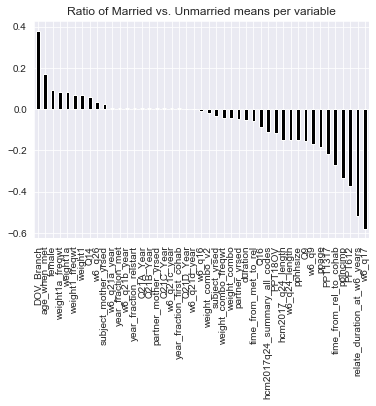

```python
# couples.groupby('S1').mean().iloc[:, 6:].T.plot(kind='bar')
sig_diffs.iloc[:-4].plot(kind='bar', color='k')
plt.title('Ratio of Married vs. Unmarried means per variable')
```

Here, the bar heights represent the largest difference between means of married and unmarried groups. The features at the ends of the graph will likely provide the most information of all continuous variables during model implementation.

```python
#Logistic Regression Model
#Drop all columns containing target information leakage
X=couples.drop(['partnership_status', 'ppmarit', 'S1', 'S2', 'w6_married', 'w6_q17', 'Q17A', 'Q21D_Year', 'w6_q21d_year', 'Q21D_Month', 'w6_q21d_month'], 1)
y=np.ravel(pd.get_dummies(couples['S1'], drop_first=True))
X=pd.get_dummies(X, drop_first=True)
X_train, X_test, y_train, y_test=train_test_split(X, y, test_size=0.1)
lrm=LogisticRegression(solver='liblinear')
lrm.fit(X_train, y_train)
print(lrm.score(X_train, y_train))
```

```
0.8822412155745489
```

```python
#Find optimal n_features to use for RFE via Recursive Feature Elimination Cross-Validation
selector= RFECV(lrm, step=2, n_jobs=-1, cv=5)
selector.fit(X_train, y_train)
print(selector.n_features_)
```

```
470
```

```python
#Run model using optimal n_features
from sklearn.feature_selection import RFE
selector=RFE(lrm, n_features_to_select=selector.n_features_)
selector.fit(X_train, y_train)
selector.score(X_train, y_train)
```

```
0.9319404874960431
```

```python
#Trim X
X_train=X_train[X_train.columns[selector.support_]]
X_test=X_test[X_test.columns[selector.support_]]
```

```python
#Tune LRM model
params_1= {'penalty': ['l1', 'l2'], 'C': [10.0**p for p in range(5)]}
lrmsearch1=GridSearchCV(LogisticRegression(solver='liblinear'),
                      param_grid=params_1, cv=5, n_jobs=-1, verbose=True)
lrmsearch1.fit(X_train, y_train)
print(lrmsearch1.best_params_, lrmsearch1.best_score_)
```

```
Fitting 5 folds for each of 10 candidates, totalling 50 fits
```

```
[Parallel(n_jobs=-1)]: Using backend LokyBackend with 4 concurrent workers.
[Parallel(n_jobs=-1)]: Done  42 tasks      | elapsed:   38.3s
[Parallel(n_jobs=-1)]: Done  50 out of  50 | elapsed:   48.1s finished
```

```
{'C': 1.0, 'penalty': 'l1'} 0.894903450459006
```

```python
#Score tuned LRM model
lrm_tuned= LogisticRegression(solver='liblinear', penalty= 'l1', C=lrmsearch1.best_params_['C'])
lrm_tuned.fit(X_train, y_train)
print('Cross validation scores: {}'.format(cross_val_score(lrm_tuned, X_train, y_train, cv=3)))
print('Mean score: {}'.format(cross_val_score(lrm_tuned, X_train, y_train, cv=3).mean()))
```

```
Cross validation scores: [0.89848197 0.88793922 0.89068441]
Mean score: 0.8923685351178259
```

```python
#Display classification results of Logistic Regression model
tn, fp, fn, tp= np.ravel(confusion_matrix(y_train, lrm_tuned.predict(X_train)))
print('Recall Score: {0:.3f}'.format(tp/(tp+fn)))
print('Precision Score: {0:.3f}'.format(tp/(tp+fp)))
print('F1 Score: {0:.3f}'.format(f1_score(y_train, lrm_tuned.predict(X_train))))
```

```
Recall Score: 0.954
Precision Score: 0.926
F1 Score: 0.940
```

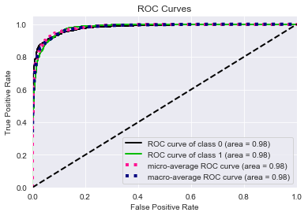

```python
#Plot ROC curve
y_probas = lrm_tuned.predict_proba(X_train)
skplt.metrics.plot_roc(y_train, y_probas)
plt.show()
```

```python
# Initialize Random Forest Model
rfc= ensemble.RandomForestClassifier()
rfc.fit(X_train, y_train)
rfc.score(X_test, y_test)
```

```
0.8774928774928775
```

```python
cross_val_score(rfc, X_train, y_train, cv=3)
```

```
array([0.88804554, 0.88224122, 0.90019011])
```

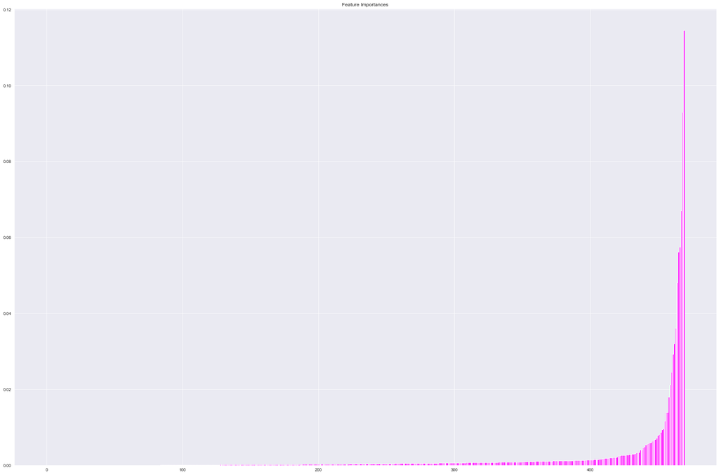

```python
#Display features importances
feats= rfc.feature_importances_

sorted_index= np.argsort(feats)
pos=np.arange(sorted_index.shape[0])
plt.figure(figsize=(30, 20))
plt.bar(pos, feats[sorted_index], color='magenta')
plt.title('Feature Importances')
plt.show()
```

```python
#Retain features using threshold 0.5% of decision trees
best_feats=[]
for feat in feats[sorted_index]:
    if feat> 0.005:
        best_feats.append(feat)
len(best_feats)
```

```
29
```

```python
#New model using top features
X=X[X.columns[sorted_index][-(len(best_feats)):]]
X_train, X_test, y_train, y_test=train_test_split(X, y, test_size=0.1)
rfc.fit(X_train, y_train)
rfc.score(X_train, y_train)
```

```
0.9943019943019943
```

```python
#Find best preliminary n_estimators
#Using smaller featureset
params_1= {'n_estimators':range(30, 81, 10)}
gsearch1=GridSearchCV(ensemble.RandomForestClassifier(min_samples_split=30,min_samples_leaf=10,
                                                          max_depth=3,max_features='sqrt'),
                      param_grid=params_1, cv=5, n_jobs=-1)
gsearch1.fit(X_train, y_train)
print(gsearch1.best_params_, gsearch1.best_score_)
```

```
{'n_estimators': 40} 0.8819246597024375
```

```python
#Find best depth & min_samples_split
params_2= {'max_depth':range(2, 8), 'min_samples_split':range(10, 51, 10)}
gsearch2=GridSearchCV(ensemble.RandomForestClassifier(n_estimators=gsearch1.best_params_['n_estimators'],
                                                      min_samples_leaf=10,max_features='sqrt'),
                      param_grid=params_2, cv=5, n_jobs=-1, verbose=True)
gsearch2.fit(X_train, y_train)
print(gsearch2.best_params_, gsearch2.best_score_)
```

```
Fitting 5 folds for each of 30 candidates, totalling 150 fits
```

```
[Parallel(n_jobs=-1)]: Using backend LokyBackend with 4 concurrent workers.
[Parallel(n_jobs=-1)]: Done  76 tasks      | elapsed:    3.6s
```

```
{'max_depth': 7, 'min_samples_split': 40} 0.894903450459006
```

```
[Parallel(n_jobs=-1)]: Done 150 out of 150 | elapsed:    7.4s finished
```

```python
#Find best leaf and max_features
params_3= {'min_samples_leaf':range(1, 6), 'max_features':range(3, 10)}
gsearch3=GridSearchCV(ensemble.RandomForestClassifier(n_estimators=gsearch1.best_params_['n_estimators'],
                                                      max_depth=gsearch2.best_params_['max_depth'],
                                                      min_samples_split=gsearch2.best_params_['min_samples_split']),
                      param_grid=params_3, cv=5, n_jobs=-1, verbose=True)
gsearch3.fit(X_train, y_train)
print(gsearch3.best_params_, gsearch3.best_score_)
```

```
[Parallel(n_jobs=-1)]: Using backend LokyBackend with 4 concurrent workers.
```

```
Fitting 5 folds for each of 35 candidates, totalling 175 fits
```

```
[Parallel(n_jobs=-1)]: Done  76 tasks      | elapsed:    4.6s
[Parallel(n_jobs=-1)]: Done 168 out of 175 | elapsed:   11.1s remaining:    0.5s
```

```
{'max_features': 5, 'min_samples_leaf': 5} 0.8987021209243431
```

```
[Parallel(n_jobs=-1)]: Done 175 out of 175 | elapsed:   11.6s finished
```

```python
rfc_tuned= ensemble.RandomForestClassifier(n_estimators=gsearch1.best_params_['n_estimators'],
                                           max_depth=gsearch2.best_params_['max_depth'],
                                           min_samples_split=gsearch2.best_params_['min_samples_split'],
                                           max_features=gsearch3.best_params_['max_features'],
                                           min_samples_leaf=gsearch3.best_params_['min_samples_leaf'], oob_score=True)
rfc_tuned.fit(X_train, y_train)
print('Tuned Model Training Set Score: {}'.format(rfc_tuned.score(X_train, y_train)))
print('OOB Score: {}'.format(rfc_tuned.oob_score_))
```

```
Tuned Model Training Set Score: 0.9094650205761317
OOB Score: 0.8942703387147831
```

```python
#Score tuned RFC model
print('Cross_validation scores: {}'.format(cross_val_score(rfc_tuned, X_train, y_train, cv=3)))
print('Mean score: {}'.format(cross_val_score(rfc_tuned, X_train, y_train, cv=3).mean()))
```

```
Cross_validation scores: [0.89563567 0.89553656 0.90114068]
Mean score: 0.8930067577407783
```

```python
#Display recall, precision, and F1 Score of RFC model
tn, fp, fn, tp= np.ravel(confusion_matrix(y_train, rfc_tuned.predict(X_train)))
print('Recall Score: {0:.3f}'.format(tp/(tp+fn)))
print('Precision Score: {0:.3f}'.format(tp/(tp+fp)))
print('F1 Score: {0:.3f}'.format(f1_score(y_train, rfc_tuned.predict(X_train))))
```

```
Recall Score: 0.953
Precision Score: 0.901
F1 Score: 0.926
```

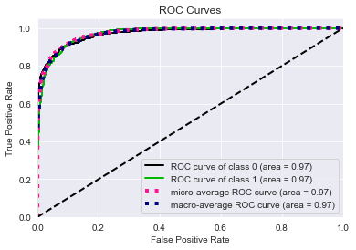

```python
#Plot ROC curve for Random Forest
y_probas = rfc_tuned.predict_proba(X_train)
skplt.metrics.plot_roc(y_train, y_probas)
plt.show()
```

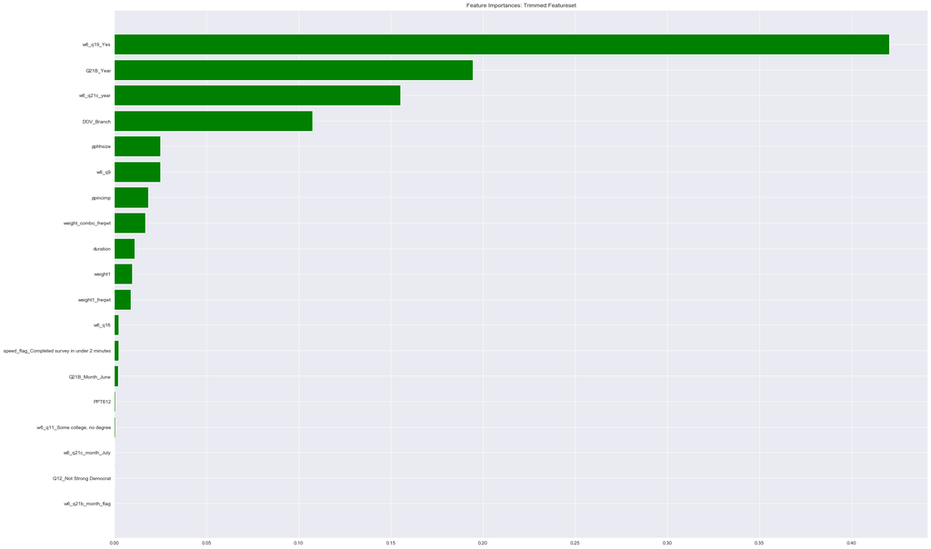

```python
#Display features importances
feats= rfc_tuned.feature_importances_

sorted_index= np.argsort(feats)
pos=np.arange(sorted_index.shape[0])+0.5
plt.figure(figsize=(30, 20))
plt.barh(pos, feats[sorted_index], color='g')
plt.yticks(pos, X.columns[sorted_index])
plt.title('Feature Importances: Trimmed Featureset')
plt.show()
```

```python
#Initialize SVC model
svc=SVC(gamma='auto')
svc.fit(X_train, y_train)
svc.score(X_train, y_train)
```

```
0.9996834441278886
```

```python
#Tune hyperparameters via GridSearch
Cs= [10.0**p for p in np.arange(-2, 5, 1)]
gammas= [10.0**p for p in np.arange(-5, 1)]
param_grid={'C':Cs, 'gamma':gammas}
gsv= GridSearchCV(svc, param_grid=param_grid, cv=5, verbose=True, n_jobs=-1)
gsv.fit(X_train, y_train)
print(gsv.best_params_, gsv.best_score_)
```

```
Fitting 5 folds for each of 42 candidates, totalling 210 fits
```

```
[Parallel(n_jobs=-1)]: Using backend LokyBackend with 4 concurrent workers.
[Parallel(n_jobs=-1)]: Done  42 tasks      | elapsed:    7.4s
[Parallel(n_jobs=-1)]: Done 192 tasks      | elapsed:   38.7s
[Parallel(n_jobs=-1)]: Done 210 out of 210 | elapsed:   42.3s finished
```

```
{'C': 10000.0, 'gamma': 1e-05} 0.6198163975941754
```

```python
#Check accuracy of tuned SVC model
svc_tuned= SVC(C=gsv.best_params_['C'], gamma=gsv.best_params_['gamma'], probability=True)
svc_tuned.fit(X_train, y_train)
svc_tuned.score(X_train, y_train)
```

```
0.9965178854067743
```

```python
#Cross Validation scores
print('Cross Validation Scores: {}'.format(cross_val_score(svc_tuned, X_train, y_train, cv=5)))
print('Mean score: {}'.format(cross_val_score(svc_tuned, X_train, y_train, cv=5).mean()))
```

```
Cross Validation Scores: [0.61708861 0.625      0.62341772 0.59651899 0.63708399]
Mean score: 0.6198218620233104
```

```python
#Display recall, precision, and F1 Score of RFC model
tn, fp, fn, tp= np.ravel(confusion_matrix(y_train, svc_tuned.predict(X_train)))
print('Recall Score: {0:.3f}'.format(tp/(tp+fn)))
print('Precision Score: {0:.3f}'.format(tp/(tp+fp)))
print('F1 Score: {0:.3f}'.format(f1_score(y_train, svc_tuned.predict(X_train))))
```

```
Recall Score: 0.998
Precision Score: 0.996
F1 Score: 0.997
```

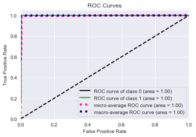

```python
#Plot ROC curve for SVC
y_probas = svc_tuned.predict_proba(X_train)
skplt.metrics.plot_roc(y_train, y_probas)
plt.show()
```

```python
#Divide train and test sets by target values for visualization
X_train=X_train.reset_index(drop=True)
X_train_full=pd.concat([X_train, pd.Series(y_train).rename('y_train')], axis=1)
X_train_married= X_train_full[X_train_full.y_train==1].drop(columns='y_train')
X_train_unmarried= X_train_full[X_train_full.y_train==0].drop(columns='y_train')
```